# Final Report: Steam Game Recommendation Engine

### Team 41

- Ashwin Sambasivam
- Nicole Rosas
- John Buergler
- Gianna Barletta
- Felix Perez Martorell

## I. Executive Summary:

We have built a Steam game recommendation engine, which will provide a handful of games it thinks a user will like based on their library information, including games they own as well as playtime in those games. The engine looks at the tags/genres of all Steam games, as well as their ratings, and attempts to find games with the closest genres and tags to a user's library. Then, it suggests the similar games that are also highly rated. We estimated the quality of our results by surveying various individuals on if they thought they would enjoy their recommended games, and determined that the model is successful in providing relevant recommendations.

## II. Introduction:

There always comes a time where you really enjoy a piece of media, whether it be a book, movie, or video game, and you're left wanting more once it's over. When it comes to games, you might want to find something in the same genre, look for games made by the same developers, or experience the same themes or aesthetics. [Steam](https://store.steampowered.com/about/) is a platform with over 50,000 games and used by many PC players to find and play said games. One problem players may face is finding something similar to games they already enjoy based on multiple factors, sometimes even being unsure of what they're looking for. This project seeks to recommend games a player would be interested in based on games they have previously played.

We do this first by performing K-Means Clustering on all Steam games based on genre and tag data, then looking at a player's library and determining from which cluster to recommend games. By doing so, we are able to recommend them highly-rated games that match their preferences.

## III. Data Description:

### Steam Game Catologue

Using the [Steamspy API](https://steamspy.com/api.php), a third-party API focused on tracking the popularity of Steam games, we collected the data of over 50,000 games found in Steam's catalogue into a dataframe. The Steamspy API is able to collect the following features for each game:

- App ID (unique key for each game)
- Title (name of game)
- Developer
- Publisher
- Number of postive and negative reviews
- Number of owners
- Average playtime
- Genre and tags

```python
import pandas as pd

# upload an example csv as a dataframe
df_steamspy = pd.read_csv('all_game_data.csv', index_col = 'appid')

# print certain columns of the dataframe for a better visualization
df_steamspy.loc[:, ['name','developer','publisher','positive','negative',
                 'owners_range_low','owners_range_high','average_forever', 'genre_Casual',
                 'genre_Action', 'tag_Multiplayer', 'tag_Competitive']].head()
```

| appid | name | developer | publisher | positive | negative | owners_range_low | owners_range_high | average_forever | genre_Casual | genre_Action | tag_Multiplayer | tag_Competitive |
| --- | --- | --- | --- | --- | --- | --- | --- | --- | --- | --- | --- | --- |
| 10 | Counter-Strike | Valve | Valve | 194710 | 4997 | 10000000 | 20000000 | 9718 | False | True | 3367 | 1592 |
| 20 | Team Fortress Classic | Valve | Valve | 5497 | 905 | 5000000 | 10000000 | 110 | False | True | 258 | 69 |
| 30 | Day of Defeat | Valve | Valve | 5055 | 557 | 5000000 | 10000000 | 372 | False | True | 203 | 0 |
| 40 | Deathmatch Classic | Valve | Valve | 1877 | 417 | 5000000 | 10000000 | 78 | False | True | 97 | 24 |
| 50 | Half-Life: Opposing Force | Gearbox Software | Valve | 13601 | 675 | 5000000 | 10000000 | 420 | False | True | 0 | 0 |

### Cleaning Tags

While genres for each game are identified by the developers, tags are features that are posted by other users on a game's store page, making them community-based judgements of what a game is like. The API represents each tag on a game through the number of users that associated a game with said tag. This leads to the problem of some tags only being chosen by only a couple players and being potentially misleading. To better categorize each game, we selected the top ten most-chosen tags for each game performed one hot encoding on the these tag columns.

```python
# uploads an example csv as a dataframe
df_clean_games = pd.read_csv('clean_games_pca.csv', index_col = 'appid')

df_clean_games.loc[:, ['name','genre_Casual', 'genre_Violent',
                'genre_Action', 'tag_Multiplayer', 'tag_Competitive','tag_Short']].head()
```

| appid | name | genre_Casual | genre_Violent | genre_Action | tag_Multiplayer | tag_Competitive | tag_Short |
| --- | --- | --- | --- | --- | --- | --- | --- |
| 10 | Counter-Strike | False | False | True | True | True | False |
| 20 | Team Fortress Classic | False | False | True | True | False | False |
| 30 | Day of Defeat | False | False | True | True | False | False |
| 40 | Deathmatch Classic | False | False | True | True | True | False |
| 50 | Half-Life: Opposing Force | False | False | True | False | False | False |

### User's Game Data

We also used the [Steam Web API](https://developer.valvesoftware.com/wiki/Steam_Web_API), an API provided by Valve which is the company behind Steam. It was used to gather a user's game data. Given the user's Steam ID (which can be found on the user's homepage), the API can view information such as the ids associated with each game they own, the playtime for each game, and even which OS they have used. However, for this project we mainly used the `appid` and `playtime_forever` features as this is what mattered most in deciding which games to recommend the user.

```python
# uploads an example csv as a dataframe
df_user = pd.read_csv('steam_user.csv', index_col = 'appid')
df_user.head()
```

| appid | playtime_forever | playtime_windows_forever | playtime_mac_forever | playtime_linux_forever | playtime_2weeks |
| --- | --- | --- | --- | --- | --- |
| 400 | 550 | 550 | 0 | 0 | NaN |
| 620 | 407 | 407 | 0 | 0 | NaN |
| 730 | 419 | 419 | 0 | 0 | NaN |
| 4000 | 225 | 0 | 0 | 0 | NaN |
| 22380 | 258 | 258 | 0 | 0 | NaN |

### Pipeline Overview

We accomplish this data collection by using 9 functions:

- `get_games()`
  - collects initial list of all steam games
- `get_game_data(int app_id)`
  - given a game's app id, returns its metadata
- `get_all_game_data(dataframe df_game)`
  - returns metadata from all games in the given dataframe
- `read_game_data_pkls()`
  - converts pkl file and reads metadata to a singular dataframe
- `get_num_owners_of_game(dataframe df_game)`
  - from given dataframe, gets the approximate number of owners for each game and appends a range of owners as a tuple for each
- `get_game_genres(dataframe df_game)`
  - from given dataframe, cleans genre data by adding columns for each unique genre and appends to each a tuple if the game is of that genre or not (if true, append `True`)
- `get_game_tags(dataframe df_frame)`
  - from given dataframe, cleans tags data by adding columns for each unique tag and appends to each a tuple if the game is of that tag or not (if true, append `True`)
- `get_user_game_data(int user_id)`
  - given a user's Steam ID, gets the users data (games they own, friends, and game playtime)
- `def get_top_tags(df_tags, n):`
  - given a dataframe of tags, collects the top 'n' tags and performs one hot encoding on them

We are collecting the metadata of multiple games and saving it in a PKL file because of the size of space it takes up. Then we convert the PKL file to be read into a dataframe. From there we clean up the dataframe. We do this by cleaning up the number of users who own each game and return as a range the number of users in string format, getting all unique game genres and performing one hot encoding to better format the data, and doing the same on the unique game tags.

### Pipeline

#### Retrieving Game Metadata

```python
# Code used to collect data on all games
import warnings
warnings.simplefilter(action="ignore", category=FutureWarning)

import numpy as np
import pandas as pd
import requests
import json

def get_games():
    """ Uses SteamSpy API to retrieve list of all Steam Games

    Returns: df_games (pd.DataFrame): data frame containing all steam games
    """
    df_games = pd.DataFrame()

    for page in range(100):
        url = f'https://steamspy.com/api.php?request=all&page={page}'
        url_text = requests.get(url).text

        if url_text == '':
            print(f'{page} pages')
            break
        else:
            games = json.loads(url_text)

            for game in games.values():
                df_games = df_games.append(game, ignore_index=True)

    df_games = df_games.sort_values('appid').reset_index(drop=True)

    return df_games
```

```python
df_games = get_games()
df_games.to_csv('steam_games.csv', index=False)
df_games.head()
```

|  | appid | name | developer | publisher | score_rank | positive | negative | userscore | owners | average_forever | average_2weeks | median_forever | median_2weeks | price | initialprice | discount | ccu |
| --- | --- | --- | --- | --- | --- | --- | --- | --- | --- | --- | --- | --- | --- | --- | --- | --- | --- |
| 0 | 10 | Counter-Strike | Valve | Valve | NaN | 194673 | 4995 | 0 | 10,000,000 .. 20,000,000 | 9539 | 436 | 229 | 82 | 999.0 | 999.0 | 0.0 | 16199 |
| 1 | 20 | Team Fortress Classic | Valve | Valve | NaN | 5495 | 905 | 0 | 5,000,000 .. 10,000,000 | 80 | 16 | 15 | 16 | 499.0 | 499.0 | 0.0 | 104 |
| 2 | 30 | Day of Defeat | Valve | Valve | NaN | 5055 | 557 | 0 | 5,000,000 .. 10,000,000 | 328 | 0 | 28 | 0 | 499.0 | 499.0 | 0.0 | 145 |
| 3 | 40 | Deathmatch Classic | Valve | Valve | NaN | 1876 | 417 | 0 | 5,000,000 .. 10,000,000 | 73 | 0 | 13 | 0 | 499.0 | 499.0 | 0.0 | 3 |
| 4 | 50 | Half-Life: Opposing Force | Gearbox Software | Valve | NaN | 13594 | 675 | 0 | 5,000,000 .. 10,000,000 | 453 | 0 | 270 | 0 | 499.0 | 499.0 | 0.0 | 139 |

```python
pd.set_option('display.max_columns', None)
```

```python
import pandas as pd
import requests
import sys
import warnings

warnings.filterwarnings("ignore", category=FutureWarning)

def get_game_data(app_id: int):
  """ Gets metadata about a given steam app.

    Args:
        app_id (int): The app ID for the game on Steam

    Returns:
        response_data (pd.Series): The API metadata for the games."""
  url = f"https://steamspy.com/api.php?request=appdetails&appid={app_id}"
  res = requests.get(url)
  if res.status_code != 200:
    print(res.status_code)
    sys.exit(0)
  res_json = res.json()
  response_data = pd.Series(res_json, dtype=object)
  return response_data

def get_all_game_data(df_games: pd.DataFrame):
  """Gets metadata about all steam apps.
    Args:
        df_games (pd.DataFrame): dataframe with all steam games

    Returns:
        df_game_data (pd.DataFrame): Dataframe with all game metadata, including tags and genres"""
  # batch requests by 1000 to reduce data loss in case of unexpected failure
  for num in range(53):
    df_game_data = pd.DataFrame(dtype=object)

    for i, app_id in enumerate(df_games['appid']):
      # to batch
      if i < 1000 * num:
        continue
      if i >= 1000 * (num+1):
        break

      print(i, app_id)
      try:
        # get game data and append to dataframe
        game_data = get_game_data(app_id)
        df_game_data = df_game_data.append(game_data, ignore_index=True)
      except Exception:
        print(i, app_id)
        raise

    # serialize dataframe and store on disk (needed to retain more complex data types)
    df_game_data.to_pickle(f"./game_data{num}.pkl")
    print(f"wrote to ./game_data{num}.pkl")
    return df_game_data
```

```python
import pandas as pd

def read_game_data_pkls():
    """ Reads metadata about all steam apps from disk.

    Returns:
        df_game_data (pd.DataFrame): Dataframe with all game metadata, including tags and genres"""
    # retrieve and deserialize all game data dataframes
    dfs = []
    for num in range(53):
        df = pd.read_pickle(f'game_data{num}.pkl')
        dfs.append(df)

    # combine all dataframes
    df_game_data = pd.concat(dfs)
    df_game_data = df_game_data.reset_index()

    # serialize and store to disk (needed to retain more complex data types)
    df_game_data.to_pickle(f"./all_game_data.pkl", protocol=4)

    return df_game_data
```

```python
import pandas as pd

def get_num_owners_of_game(df_game_data: pd.DataFrame):
    """ Cleans owner count data on a dataframe of steam game metadata.

    Args:
        df_game_data (pd.DataFrame): Dataframe with steam game metadata
    Returns:
        df_game_data (pd.DataFrame): same dataframe with cleaned up owner data"""
    # split the number of owners into low and high range values
    num_owners = df_game_data['owners'].map(lambda s: [int(num_str.replace(',', '')) for num_str in s.split(' .. ')])
    df_game_data['owners_range_low'] = num_owners.map(lambda p: p[0])
    df_game_data['owners_range_high'] = num_owners.map(lambda p: p[1])

    # remove old owners column
    del df_game_data['owners']

    return df_game_data
```

```python
def get_game_genres(df_game_data: pd.DataFrame):
  """Cleans genre data on a dataframe of steam game metadata.

    Args:
        df_game_data (pd.DataFrame): Dataframe with steam game metadata
    Returns:
        df_game_data (pd.DataFrame): same dataframe with cleaned up genre data"""
  # get all possible genres
  genres = set()
  for genre_list in df_game_data['genre'].map(lambda s: s.split(', ')):
      for g in genre_list:
          if g != '':
              genres.add(g)

  # one hot encode genres
  for genre in genres:
      df_game_data[f'genre_{genre}'] = df_game_data['genre'].str.contains(genre)

  # remove old genre column
  del df_game_data['genre']

  return df_game_data
```

```python
def get_game_tags(df_game_data: pd.DataFrame):
  """Cleans tag data on a dataframe of steam game metadata.

    Args:
        df_game_data (pd.DataFrame): Dataframe with steam game metadata
    Returns:
        df_game_data (pd.DataFrame): same dataframe with cleaned up tag data"""
  # get all possible tags
  tags = set()
  for tag_list in df_game_data['tags'].map(lambda d: d.keys() if d else ()):
      for t in tag_list:
          if t != '':
              tags.add(t)

  # one hot encode tags
  for tag in tags:
      print(tag)
      tag_series = df_game_data['tags'].map(lambda d: d.get(tag, 0) if d else 0)
      df_game_data[f'tag_{tag}'] = tag_series
      # to prevent excessive fragmentation
      df_game_data = df_game_data.copy()

  # remove old tags column
  del df_game_data['tags']

  return df_game_data
```

```python
# TAKES AROUND 5 HOURS
df_games = get_games()
get_game_data(df_games)
```

```python
# read all steam game metadata from disk
df_game_data = read_game_data_pkls()

# clean up data
df_game_data = get_num_owners_of_game(df_game_data)
df_game_data = get_game_genres(df_game_data)
df_game_data = get_game_tags(df_game_data)

# store in CSV
df_game_data.to_csv('all_processed_game_data.csv', index=False)
```

```python
df_game_data.head()
```

|  | appid | name | developer | publisher | score_rank | positive | negative | userscore | average_forever | average_2weeks | ... | tag_3D Fighter | tag_Bullet Hell | tag_Turn-Based | tag_Video Production | tag_Collectathon | tag_Sokoban | tag_Mod | tag_2D Fighter | tag_Asymmetric VR | tag_Side Scroller |
| --- | --- | --- | --- | --- | --- | --- | --- | --- | --- | --- | --- | --- | --- | --- | --- | --- | --- | --- | --- | --- | --- |
| 0 | 10 | Counter-Strike | Valve | Valve | NaN | 194710 | 4997 | 0 | 9718 | 424 | ... | 0 | 0 | 0 | 0 | 0 | 0 | 0 | 0 | 0 | 0 |
| 1 | 20 | Team Fortress Classic | Valve | Valve | NaN | 5497 | 905 | 0 | 110 | 16 | ... | 0 | 0 | 0 | 0 | 0 | 0 | 36 | 0 | 0 | 0 |
| 2 | 30 | Day of Defeat | Valve | Valve | NaN | 5055 | 557 | 0 | 372 | 0 | ... | 0 | 0 | 0 | 0 | 0 | 0 | 0 | 0 | 0 | 0 |
| 3 | 40 | Deathmatch Classic | Valve | Valve | NaN | 1877 | 417 | 0 | 78 | 0 | ... | 0 | 0 | 0 | 0 | 0 | 0 | 0 | 0 | 0 | 0 |
| 4 | 50 | Half-Life: Opposing Force | Gearbox Software | Valve | NaN | 13601 | 675 | 0 | 420 | 0 | ... | 0 | 0 | 0 | 0 | 0 | 0 | 0 | 0 | 0 | 0 |

5 rows × 481 columns

#### Retrieving User Metadata

```python
# Gets the user's game data.
import pandas as pd

key = '9F9BE04C0EAADB89408D7DD43B1E27B1'

def get_user_game_data(key, steam_id):
    """Gets the user data text with games, game count, playtime, etc.

    Args:
        key (str) : key used to perform request
        steam_id (int) : The user ID for steam

    Returns:
        url_text : The API data for the user's games."""

    url = f'https://api.steampowered.com/IPlayerService/GetOwnedGames/v0001/?key={key}&steamid={steam_id}&format=json'
    url_text = requests.get(url).text
    return json.loads(url_text)['response']['games']
```

```python
steam_id = '76561198141730695'

df_user = pd.DataFrame(get_user_game_data(key, steam_id))
df_user = df_user.sort_values('appid').reset_index(drop=True)
df_user.to_csv('steam_user.csv', index=False)
df_user.head()
```

|  | appid | playtime_forever | playtime_windows_forever | playtime_mac_forever | playtime_linux_forever | playtime_2weeks |
| --- | --- | --- | --- | --- | --- | --- |
| 0 | 400 | 550 | 550 | 0 | 0 | NaN |
| 1 | 620 | 407 | 407 | 0 | 0 | NaN |
| 2 | 730 | 419 | 419 | 0 | 0 | NaN |
| 3 | 4000 | 225 | 0 | 0 | 0 | NaN |
| 4 | 22380 | 258 | 258 | 0 | 0 | NaN |

#### Cleaning Tags

```python
import pandas as pd

# Retrieves data on all games
df_games = pd.read_csv('all_game_data.csv')
df_games.head()
```

|  | appid | name | developer | publisher | score_rank | positive | negative | userscore | average_forever | average_2weeks | ... | tag_3D Fighter | tag_Bullet Hell | tag_Turn-Based | tag_Video Production | tag_Collectathon | tag_Sokoban | tag_Mod | tag_2D Fighter | tag_Asymmetric VR | tag_Side Scroller |
| --- | --- | --- | --- | --- | --- | --- | --- | --- | --- | --- | --- | --- | --- | --- | --- | --- | --- | --- | --- | --- | --- |
| 0 | 10 | Counter-Strike | Valve | Valve | NaN | 194710 | 4997 | 0 | 9718 | 424 | ... | 0 | 0 | 0 | 0 | 0 | 0 | 0 | 0 | 0 | 0 |
| 1 | 20 | Team Fortress Classic | Valve | Valve | NaN | 5497 | 905 | 0 | 110 | 16 | ... | 0 | 0 | 0 | 0 | 0 | 0 | 36 | 0 | 0 | 0 |
| 2 | 30 | Day of Defeat | Valve | Valve | NaN | 5055 | 557 | 0 | 372 | 0 | ... | 0 | 0 | 0 | 0 | 0 | 0 | 0 | 0 | 0 | 0 |
| 3 | 40 | Deathmatch Classic | Valve | Valve | NaN | 1877 | 417 | 0 | 78 | 0 | ... | 0 | 0 | 0 | 0 | 0 | 0 | 0 | 0 | 0 | 0 |
| 4 | 50 | Half-Life: Opposing Force | Gearbox Software | Valve | NaN | 13601 | 675 | 0 | 420 | 0 | ... | 0 | 0 | 0 | 0 | 0 | 0 | 0 | 0 | 0 | 0 |

5 rows × 481 columns

```python
import numpy as np

# Collects all tags and their corresponding data
# for each game, storing them as a new dataframe
tag_list = [col for col in df_games.columns if 'tag' in col]
df_tags = df_games.loc[:, tag_list]

def get_top_tags(df_tags, n=10):
    """ returns dataframe where each game's top n tags have a value of True and
        all other tags have a value of False

    Args:
        df_tags (pd.DataFrame): dataframe of tags
        n (int): top n tags, default is 10

    Returns:
        df_top_tags (df): True for tags in the top n for that game, and false otherwise
    """
    # returns value for top tags, NaN for those not in the top
    top_tags = df_tags.apply(pd.Series.nlargest, axis=1, n=n)

    # replaces values and NaN with bool values
    df_top_tags = top_tags.applymap(lambda x: True if x > 0 else False)

    return df_top_tags
```

```python
# Collects the top 10 tags for each game
df_top_tags = get_top_tags(df_tags)

# Adds appid from all game data to this dataframe
df_top_tags['appid'] = df_games['appid']
df_top_tags.head()
```

|  | tag_1980s | tag_1990's | tag_2.5D | tag_2D | tag_2D Fighter | tag_2D Platformer | tag_360 Video | tag_3D | tag_3D Fighter | tag_3D Platformer | ... | tag_Well-Written | tag_Werewolves | tag_Western | tag_Word Game | tag_World War I | tag_World War II | tag_Wrestling | tag_Zombies | tag_e-sports | appid |
| --- | --- | --- | --- | --- | --- | --- | --- | --- | --- | --- | --- | --- | --- | --- | --- | --- | --- | --- | --- | --- | --- |
| 0 | False | True | False | False | False | False | False | False | False | False | ... | False | False | False | False | False | False | False | False | False | 10 |
| 1 | False | True | False | False | False | False | False | False | False | False | ... | False | False | False | False | False | False | False | False | False | 20 |
| 2 | False | False | False | False | False | False | False | False | False | False | ... | False | False | False | False | False | True | False | False | False | 30 |
| 3 | False | False | False | False | False | False | False | False | False | False | ... | False | False | False | False | False | False | False | False | False | 40 |
| 4 | False | True | False | False | False | False | False | False | False | False | ... | False | False | False | False | False | False | False | False | False | 50 |

5 rows × 429 columns

#### Final Dataframe

```python
# Collects all genres and their corresponding data
# for each game, storing them as a new dataframe
genre_list = [col for col in df_games.columns if 'genre' in col]
df_genres = df_games.loc[:, genre_list]

# Adds appid from all game data to this dataframe
df_genres['appid'] = df_games['appid']

# Merge genre and tag dataframes
df_games_clean = df_games.loc[:, ['appid', 'name']]
df_games_clean = df_games_clean.merge(df_genres, on='appid')
df_games_clean = df_games_clean.merge(df_top_tags, on='appid')

df_games_clean.head()
```

|  | appid | name | genre_Sexual Content | genre_Nudity | genre_Casual | genre_Early Access | genre_Free to Play | genre_Movie | genre_Simulation | genre_Violent | ... | tag_Web Publishing | tag_Well-Written | tag_Werewolves | tag_Western | tag_Word Game | tag_World War I | tag_World War II | tag_Wrestling | tag_Zombies | tag_e-sports |
| --- | --- | --- | --- | --- | --- | --- | --- | --- | --- | --- | --- | --- | --- | --- | --- | --- | --- | --- | --- | --- | --- |
| 0 | 10 | Counter-Strike | False | False | False | False | False | False | False | False | ... | False | False | False | False | False | False | False | False | False | False |
| 1 | 20 | Team Fortress Classic | False | False | False | False | False | False | False | False | ... | False | False | False | False | False | False | False | False | False | False |
| 2 | 30 | Day of Defeat | False | False | False | False | False | False | False | False | ... | False | False | False | False | False | False | True | False | False | False |
| 3 | 40 | Deathmatch Classic | False | False | False | False | False | False | False | False | ... | False | False | False | False | False | False | False | False | False | False |
| 4 | 50 | Half-Life: Opposing Force | False | False | False | False | False | False | False | False | ... | False | False | False | False | False | False | False | False | False | False |

5 rows × 463 columns

### Visualizations

```python
df_games = pd.read_csv('all_game_data.csv')
```

```python
# get net of positive/negative reviews
def pos_neg_ratio(game):
  """ gets the ratio of positive to negative reviews for a game
  Args: - game (series): row within dataframe
  Returns: - ratio of pos/neg
  """
  if game[7] != 0:
    return game[6]/game[7]
  # account for negative reviews=0 which creates infinite number
  else:
    return game[6]
df_games['pos_neg_ratio'] = df_games['positive']/df_games['negative']
```

```python
df_games.head(5)
```

|  | index | appid | name | developer | publisher | score_rank | positive | negative | userscore | average_forever | ... | tag_Bullet Hell | tag_Turn-Based | tag_Video Production | tag_Collectathon | tag_Sokoban | tag_Mod | tag_2D Fighter | tag_Asymmetric VR | tag_Side Scroller | pos_neg_ratio |
| --- | --- | --- | --- | --- | --- | --- | --- | --- | --- | --- | --- | --- | --- | --- | --- | --- | --- | --- | --- | --- | --- |
| 0 | 0 | 10 | Counter-Strike | Valve | Valve | NaN | 194710 | 4997 | 0 | 9718 | ... | 0 | 0 | 0 | 0 | 0 | 0 | 0 | 0 | 0 | 38.965379 |
| 1 | 1 | 20 | Team Fortress Classic | Valve | Valve | NaN | 5497 | 905 | 0 | 110 | ... | 0 | 0 | 0 | 0 | 0 | 36 | 0 | 0 | 0 | 6.074033 |
| 2 | 2 | 30 | Day of Defeat | Valve | Valve | NaN | 5055 | 557 | 0 | 372 | ... | 0 | 0 | 0 | 0 | 0 | 0 | 0 | 0 | 0 | 9.075404 |
| 3 | 3 | 40 | Deathmatch Classic | Valve | Valve | NaN | 1877 | 417 | 0 | 78 | ... | 0 | 0 | 0 | 0 | 0 | 0 | 0 | 0 | 0 | 4.501199 |
| 4 | 4 | 50 | Half-Life: Opposing Force | Gearbox Software | Valve | NaN | 13601 | 675 | 0 | 420 | ... | 0 | 0 | 0 | 0 | 0 | 0 | 0 | 0 | 0 | 20.149630 |

5 rows × 483 columns

```python
# initialize dataframe of data on publishers
df_games_pub = pd.DataFrame()

# group by publisher
publisher = df_games.groupby(["publisher"])
# get average net positive reviews and # of games per publisher
df_games_pub['avg_pos_ratio'] = publisher['pos_neg_ratio'].mean()
df_games_pub['avg_price'] = publisher['price'].mean()
df_games_pub['num_games'] = publisher['appid'].count()
df_games_pub['avg_owners'] = publisher['owners_range_high'].mean()

# price is in cents, convert to dollars
df_games_pub['avg_price'] = df_games_pub['avg_price'].apply(lambda x: x/100)

# put owners into 100,000s to improve readability
df_games_pub['avg_owners'] = df_games_pub['avg_owners'].apply(lambda x: x//100000 if x<1000000 else x//1000000)
```

```python
# limit to publishers w >5 games
n_bool = df_games_pub.loc[:, 'num_games'] >5
df_games_pub = df_games_pub.loc[n_bool]
```

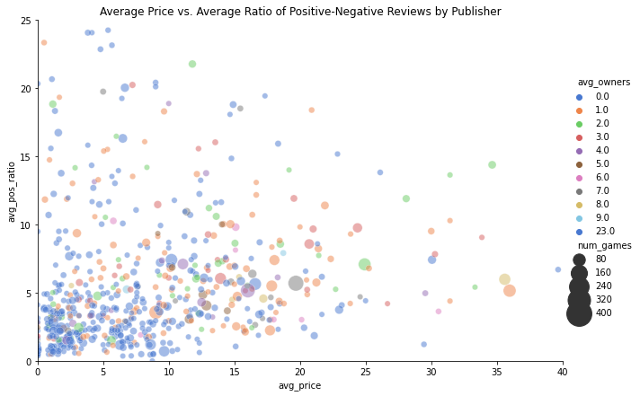

```python
import seaborn as sns
import matplotlib.pyplot as plt

grid = sns.relplot(x="avg_price", y="avg_pos_ratio", size="num_games",
            hue="avg_owners",sizes=(40, 800), alpha=.5, palette="muted",
            height=6, aspect = 1.5, data=df_games_pub)
plt.xlim(0,40)
plt.ylim(0,25)
plt.title('Average Price vs. Average Ratio of Positive-Negative Reviews by Publisher')
```

The publishers' colors are based on the average number of owners per game, using the high end of the range estimate. There does not appear to be an obvious correlation between average price and average number of owners, implying that gamers may be willing to pay more for a game if they believe the price to be worth it. It also does not account for any sales that may have occurred.

There also does not appear to be a correlation between the number of games a publisher has put out and the average ratio of positive reviews per game, meaning a well-established publisher does not necessarily put out better games than a smaller publisher.

```python
genre_dict = {}

# Collects the number of games in each genre into a dictionary
for genre in df_clean_games.columns[1:34]:
    genre_dict[genre] = df_clean_games[genre].value_counts()[1]
```

```python
# Sorts the genres in descending order and collects the 10 genres
# with the highest number of games
top_genres = sorted(genre_dict.items(), key=lambda x: x[1], reverse=True)[:10]

# Reconverts genres and corresponding games into a dictionary
plot_dict = {}
for genre in top_genres:
    plot_dict[genre[0]] = genre[1]
```

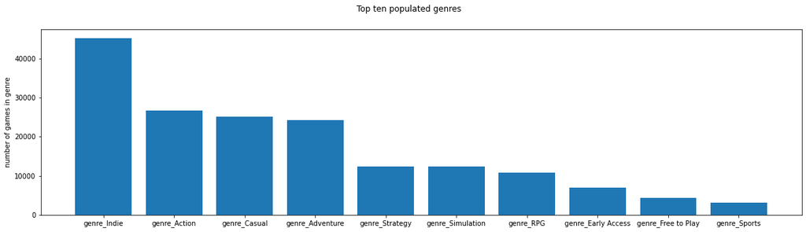

```python
import matplotlib.pyplot as plt

# Plots the top ten most populated genres
plt.bar(plot_dict.keys(), plot_dict.values())
plt.suptitle('Top ten populated genres')
plt.ylabel('number of games in genre')
plt.gcf().set_size_inches(20, 5)
```

This bar plot demonstrates the ten genres with the highest number of games. Since a game can have multiple genres, the same game can contribute to multiple genres meaning there is an overlap between them. However in total, we can see that the Indie genre has the largest number of games. This graph gives us an idea on how easy it will be to find games in the same genre, with the ones plotted here being the easiest to find recommendations for since there are a lot of potential games to choose.

## IV. Method:

### ML Approach - Clustering

We chose to use a [clustering](https://www.javatpoint.com/clustering-in-machine-learning) algorithm since we want to output a collection of games most similar to what the user already plays. To do this, it is best to organize Steam's entire library into similar groups based on attributes that categorize different games. We can then find the group that contains the most similarity to a user's most-played games and recommend all the games in that group.

This is better than using a Classifer or Regression since clustering isn't supervised, meaning it automatically determines what games are most similar based on the given data and groups them accordingly rather than attempting to identify individual games that are closest to matching specific attributes.

We believe a user would enjoy a game they haven't played if it shares similar attributes to games they have already played. These attributes will include:

- Genre
- Tags

With this data, we will perform clustering on all Steam games available on the platform. Once the games have been grouped together based on their similarities made up of the attributes described above, we proceed to the final step.

We assume users prefer games that are highly rated by other players, thus we will also take into account user reviews of each game.

Our final assumption is that users prefer games that are similar to the most-played games in their library. This means that once the games are grouped together, we would recommend the highest-rated games from the cluster containing the largest amount of games and/or total playtime from the user's library, representing the games most similar to the user's preferences.

Before performing clustering, we also use [Principle Component Analysis](https://royalsocietypublishing.org/doi/10.1098/rsta.2015.0202) (PCA) for 3 reasons:

- Reduces dimensionality (allowing us to plot in 2-dimensions with similar games close to each other)
- Scale Normalization
- Removes correlation between different features (preventing similar genres/tags distorting the clusters)

Potential pitfalls include the fact that we are only clustering with genres and tags, meaning several features from games are being ignored which could provide even more accurate clusters. Another problem is the fact that clustering is unsupervised, making the results and accuracy of the clusters and our final results hard to objectively prove.

## V. Results:

### PCA and Updated Dataframe

```python
# Contains prefixes for genres and tags
tag_prefix_tup = 'genre_', 'tag_'

def is_tag(feat, tag_prefix_tup=tag_prefix_tup):
    """ returns true if a given feature is a genre/tag

    Args:
        feat (str): feature being analyzed
        tag_prefix_tup (tuple(str)): list of recognized prefixes

    Returns:
        _ (bool): True/False depending on whether or not feature is a genre/tag
    """
    for tag_prefix in tag_prefix_tup:
        if feat.startswith(tag_prefix):
            return True

    return False

def strip_tag(feat, tag_prefix_tup=tag_prefix_tup):
    """ returns feature having removed recognized prefixes

    Args:
        feat (str): feature being analyzed
        tag_prefix_tup (tuple(str)): list of recognized prefixes

    Returns:
        feat (str): modified version of feat with removed prefixes
    """
    for tag_prefix in tag_prefix_tup:
        if feat.startswith(tag_prefix):
            feat = feat[len(tag_prefix):]

    return feat

def get_game_tag_tuple(game_row, tag_list=None):
    """ builds a list of all genres/tags which a game has

    Args:
        game_row (pd.Series): game to collect genres/tags from
        tag_list (list(str)): list of features from game recognized as genres/tags

    Returns:
        game_tag_list (tuple(str)): list of stripped genres/tags for the game
    """
    if tag_list is None:
        # re-compute
        tag_list = list(filter(is_tag, df_games_clean.columns))

    # collect all tags of a particular game
    game_tag_list = list()
    for feat in tag_list:
        if game_row[feat]:
            game_tag_list.append(strip_tag(feat))

    return tuple(game_tag_list)
```

```python
from sklearn.decomposition import PCA
import plotly.express as px

# Collects genres and tags used as data to create PCA
genres = list(df_genres.columns[:-1])
tags = list(df_top_tags.columns[:-1])

x_feat_list = genres + tags
x = df_games_clean.loc[:, x_feat_list]

# Creates PCA and uses collected data to determine pca values
pca = PCA(n_components=2, whiten=True)
y = pca.fit_transform(x)

# Adds these pca values to the dataframe containing all the game data
df_games_clean['pca0'] = y[:, 0]
df_games_clean['pca1'] = y[:, 1]

# Adds column containing genres and tags to dataframe
# to show them in the PCA graph
df_games_clean['genres/tags'] = df_games_clean.apply(get_game_tag_tuple, axis=1)

# Plots the PCA
fig = px.scatter(df_games_clean, x='pca0', y='pca1', hover_data=['name', 'genres/tags'])
fig.show()
fig.write_html("pca.html")
```

#### ***Refer to "pca.html" for PCA graph

```python
# PCA components and genre/tag list for each tag added to our data
df_clean_games.loc[:, ['name', 'pca0', 'pca1', 'genres/tags']].head()
```

| appid | name | pca0 | pca1 | genres/tags |
| --- | --- | --- | --- | --- |
| 10 | Counter-Strike | -1.184409 | 1.782121 | ('Action', "1990's", 'Action', 'Classic', 'Com... |
| 20 | Team Fortress Classic | -1.195063 | 1.736644 | ('Action', "1990's", 'Action', 'Class-Based', ... |
| 30 | Day of Defeat | -1.179957 | 1.780962 | ('Action', 'Action', 'Class-Based', 'Classic',... |
| 40 | Deathmatch Classic | -1.234304 | 1.788301 | ('Action', 'Action', 'Arena Shooter', 'Classic... |
| 50 | Half-Life: Opposing Force | -1.429566 | 0.926000 | ('Action', "1990's", 'Action', 'Adventure', 'A... |

After the PCA, the graph now has games with similar genres and tags located close to each other as seen by hovering over the provided plotly graph, making it ideal for clustering with these features, allowing us to move on to the next step.

### Choosing the K value and Clustering

Since we are using K-Means Clustering, we have to select the ideal number of clusters 'k'. When choosing a k-value for the clustering of the dataset, we tested all values of k from 2 to 30 to check the mean distance as clusters are added. We then produced a graph to decide what amount of clusters would be a good amount so as to not overfit the data, while also minimizing the mean distance from the centroid. The graph ended up looking like this:

```python
from sklearn.cluster import KMeans
import matplotlib.pyplot as plt
import seaborn as sns

x = df_games_pca[['pca0', 'pca1']].to_numpy()

mean_d_dict = dict()
for n_clusters in range(2, 30):
    # fit kmeans
    kmeans = KMeans(n_clusters=n_clusters)
    kmeans.fit(x)
    y = kmeans.predict(x)

    # compute & store mean distance
    mean_d = -kmeans.score(x)
    mean_d_dict[n_clusters] = mean_d

    # plot clustering
    #plt.figure()
    #sns.scatterplot(x=x[:, 0], y=x[:, 1], s=100, hue=y, palette='Set2')
    #plt.suptitle(f'{n_clusters} clusters has mean_d: {mean_d:.0f}')
    #plt.gca().get_legend().remove()
    #plt.gcf().set_size_inches(18, 9)
```

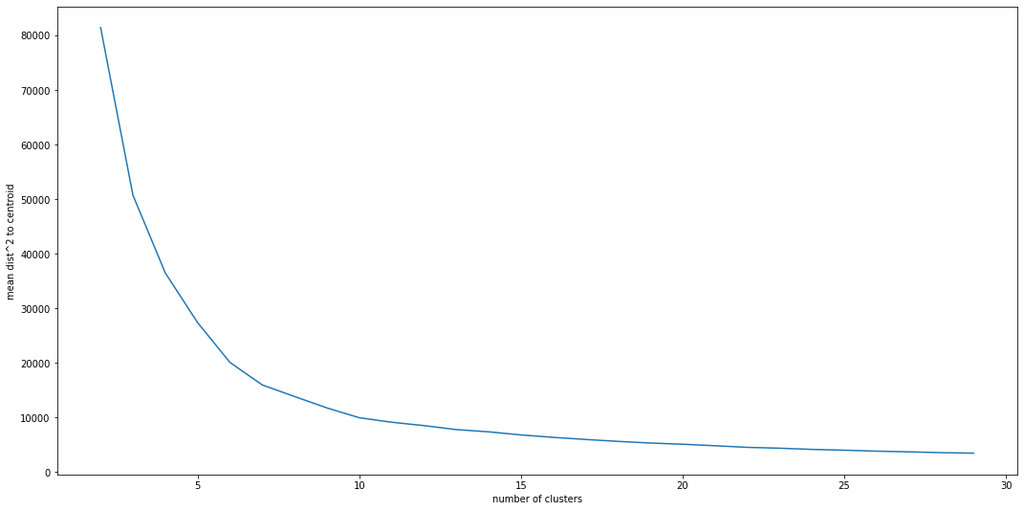

```python
plt.plot(mean_d_dict.keys(), mean_d_dict.values())
plt.xlabel('number of clusters')
plt.ylabel('mean dist^2 to centroid')
plt.gcf().set_size_inches(18, 9)
```

Looking at this graph, we initially came to the conclusion that a good elbow to minimize mean_d while not overfitting was approximately 7

```python
from sklearn.cluster import KMeans
import plotly.express as px
import seaborn as sns

x = df_games_pca[['pca0', 'pca1']].to_numpy()

mean_d_dict = dict()
n_clusters = 7
# fit kmeans
kmeans = KMeans(n_clusters=n_clusters)
kmeans.fit(x)
y = kmeans.predict(x)

df_games_pca['cluster'] = y

fig = px.scatter(df_games_pca, x='pca0', y='pca1', color='cluster', hover_data=['appid', 'name', 'genres/tags'])
fig.show()

fig.write_html("pca_k_7.html")
```

#### ***Refer to "pca_k_7.html" for K-Means Clustering graph with k=7

### Considerations

While this is a completely justified choice, what scared us off was the sheer number of values that are contained within each cluster. For all of the types of games on the platform, 7 groups does not feel like a reasonable number of types. We decided that 10 would be a much better choice, still avoiding an overfit dataset but allowing a more narrowed down group for the user.

```python
from sklearn.cluster import KMeans
import plotly.express as px
import seaborn as sns

x = df_games_pca[['pca0', 'pca1']].to_numpy()

mean_d_dict = dict()
n_clusters = 10
# fit kmeans
kmeans = KMeans(n_clusters=n_clusters)
kmeans.fit(x)
y = kmeans.predict(x)

df_games_pca['cluster'] = y

fig = px.scatter(df_games_pca, x='pca0', y='pca1', color='cluster', hover_data=['appid', 'name', 'genres/tags'])
fig.show()

fig.write_html("pca_k_10.html")
```

#### ***Refer to "pca_k_10.html" for K-Means Clustering graph with k=10

It is important to remember that the clustering is not only separating games by genre, but also tags that are assigned by the community. It is very possible that two games could be of different “genres” but enjoyed by a certain community.

### Getting user data from a Steam ID with API calls.

Next was the necessary steam user information to be able to find which cluster a user belongs to. This was simple with the Steam Web API, as long as a user’s profile is marked to publicly share library information and playtime. An important thing to consider is which games are most often enjoyed by a user. The way we decided to approach this was to take their library and playtime, and calculate which games were of higher than average playtime. We consolidated this list to app ID and playtime.

```python
# Gets the user's game data.
import pandas as pd

key = '9F9BE04C0EAADB89408D7DD43B1E27B1'

def get_user_game_data(key, steam_id):
    """Gets the user data text with games, game count, playtime, etc.

    Args:
        key (str) : key used to perform request
        steam_id (int) : The user ID for steam

    Returns:
        url_text : The API data for the user's games."""

    url = f'https://api.steampowered.com/IPlayerService/GetOwnedGames/v0001/?key={key}&steamid={steam_id}&format=json'
    url_text = requests.get(url).text
    return json.loads(url_text)['response']['games']
```

```python
import requests
import json
import pandas as pd

user = '76561198836545533'
#"76561198083464351"

# gets data of games played by user
users_games = get_user_game_data(key, user)

# empty dataframe to hold game's id and playtime
user_games_df = pd.DataFrame()

# empty list of gameids
list_id = []
# empty list of playtimes (in minutes)
list_playtime = []

# goes through each game data of users_games
for game in users_games:
    # gets game's id
    gid = game["appid"]
    # gets game's playtime
    playtime = game["playtime_forever"]

    # appends id to list
    list_id.append(gid)
    # appends playtime to list
    list_playtime.append(playtime)

# appends lists of ids and playtimes to df of games
user_games_df['id'] = list_id
user_games_df['playtime'] = list_playtime

# gets average playtime
# we only want games that the user plays the most
# (so higher than average) to tailor game recs
avg = user_games_df["playtime"].mean()

# boolean which determines if game has higher playtime than average
s_bool = user_games_df['playtime'] > avg

# games with higher playtime than average are put into new df
most_played = user_games_df.loc[s_bool,:]

user_games_df.sort_values(by=['playtime'], ascending=False)
```

|  | id | playtime |
| --- | --- | --- |
| 21 | 252950 | 4722 |
| 14 | 49520 | 1852 |
| 34 | 298600 | 1588 |
| 47 | 387290 | 1385 |
| 82 | 680420 | 1227 |
| ... | ... | ... |
| 1 | 220 | 0 |
| 43 | 363440 | 0 |
| 50 | 413420 | 0 |
| 51 | 225540 | 0 |
| 83 | 1180660 | 0 |

84 rows × 2 columns

Some considerations to take into account that we would like to tackle in the future are playtime weight and developer. We might want to consider that someone has played a game noticeably more than others, which would absolutely affect what games they would like to have recommended to them.

### Narrowing down Recommendations Based on Cluster and User Data

Next, we focused our approach on counting the cluster that was most common in a user's library and finding the highest rated games out of those to return. The below function completes that task by compiling a dictionary that holds a count of the clusters contained in the most played games list.

```python
# dump

# empty dictionary where id is key and playtime is value
dict_id_count = {}

# make df's ids into list
ids = df_games_pca['appid'].tolist()
# make df's clusters into list
clus = df_games_pca['cluster'].tolist()

# go through ids
for key in ids:
    # go through values
    for value in clus:
        # make first value found a value to key
        dict_id_count[key] = value
        # then remove the value from list
        clus.remove(value)
        # break the for loop
        break

# counter dictionary
cluster_coun = {}

# to find the clusters of the game ids from most played df
for g_id in most_played['id']:
    # we can find cluster by dictionary lookup
    clust = dict_id_count.get(g_id, 0)
    # counter to count what luster has most games played by user
    if clust != -1:
        cluster_coun[clust] = cluster_coun.get(clust, 0) + 1
    else:
        continue

print(cluster_coun)
#dict_id_count


#Get the cluster that is most common.
cluster_m = max(cluster_coun, key=cluster_coun.get)
print(cluster_m)
```

```
{3: 7, 7: 3, 5: 2, 2: 1, 1: 1, 6: 1}
3
```

```python
# get games in cluster = cluster_m that have best review ratio
import pandas as pd

df_reviews = pd.read_csv('steam_games.csv')

#df_reviews.head()

users_games = user_games_df['id'].tolist()

for game in users_games:
    df_reviews = df_reviews[df_reviews['appid'] != game]


pos_score = df_reviews['positive'].tolist()
neg_score = df_reviews['negative'].tolist()

ratio = []

for index in range(len(pos_score)):

    if neg_score[index] == 0:
        r = 0
    else:
        r = pos_score[index]/(neg_score[index] + pos_score[index])
    ratio.append(r)

df_reviews = df_reviews.iloc[:,[0,5,6]]

df_reviews['ratio'] = pd.Series(ratio)

df_reviews['cluster'] = ''

for appid in dict_id_count.keys():

    b_bool = df_reviews.loc[:,'appid'] == appid
    df_reviews.loc[b_bool, 'cluster'] = dict_id_count[appid]

#print(dict_id_count)
df_reviews.head()
```

|  | appid | positive | negative | ratio | cluster |
| --- | --- | --- | --- | --- | --- |
| 0 | 10 | 194673 | 4995 | 0.974983 | 3 |
| 1 | 20 | 5495 | 905 | 0.858594 | 3 |
| 2 | 30 | 5055 | 557 | 0.900748 | 3 |
| 3 | 40 | 1876 | 417 | 0.818142 | 3 |
| 4 | 50 | 13594 | 675 | 0.952695 | 7 |

```python
def narrowed_reviews(df_reviews, ratio, upper):
    """Returns the reviews that have a higher user ratio than 0.9 and also
    have a total number of reviews in range provided. Note that lower limit is set
    at 500 to avoid a 100% positive rate solely due to lack of total reviews.

    Args:
        df_reviews (DataFrame): the dataframe of games with their assiated review value
        ratio (int): the desired lower limit for reviews.
        upper (int): the upper limit for number of reviews to adjust popularity.

    Returns:
        df_reviews_narrowed (DataFrame): the dataframe adjusted for reviews."""

    df_reviews_narrowed = df_reviews[df_reviews['ratio'] > ratio]

    df_reviews_narrowed = df_reviews_narrowed[df_reviews['cluster'] == cluster_m]

    df_reviews_narrowed = df_reviews_narrowed[df_reviews['positive'] + df_reviews['negative'] > 500]
    df_reviews_narrowed = df_reviews_narrowed[df_reviews['positive'] + df_reviews['negative'] < upper]

    return df_reviews_narrowed

df_reviews_narrowed = narrowed_reviews(df_reviews, 0.9, 20000)

df_reviews_narrowed.shape
```

```
(146, 5)
```

```python
df_reviews_narrowed = df_reviews_narrowed.sort_values(by=['ratio'], ascending=False)
df_reviews_narrowed
```

|  | appid | positive | negative | ratio | cluster |
| --- | --- | --- | --- | --- | --- |
| 36667 | 1206240 | 913 | 123 | 0.982301 | 3 |
| 34519 | 1142500 | 2876 | 377 | 0.978947 | 3 |
| 7352 | 396480 | 706 | 187 | 0.977930 | 3 |
| 3623 | 296490 | 3314 | 130 | 0.977011 | 3 |
| 34207 | 1133430 | 302 | 526 | 0.975401 | 3 |
| ... | ... | ... | ... | ... | ... |
| 2783 | 265590 | 1702 | 648 | 0.901208 | 3 |
| 3035 | 275530 | 828 | 268 | 0.901070 | 3 |
| 35467 | 1170060 | 520 | 25 | 0.901068 | 3 |
| 2 | 30 | 5055 | 557 | 0.900748 | 3 |
| 1579 | 207930 | 744 | 335 | 0.900561 | 3 |

146 rows × 5 columns

### Final Output to a User given their Steam ID

```python
import requests
import json

def return_recommended_games(total_games):

    rec_games = df_reviews_narrowed['appid'][0:total_games].tolist()

    print('Here are your recommended games: ')
    for rec in rec_games:
        url = f'http://store.steampowered.com/api/appdetails?appids={int(rec)}'
        html = requests.get(url).text
        #print(url)
        dict_game = json.loads(html)
        print(dict_game[str(int(rec))]['data']['name'])

return_recommended_games(10)
```

```
Here are your recommended games:
Talvisota - Winter War
Fun with Ragdolls: The Game
Battlevoid: Harbinger
GemCraft - Chasing Shadows
Ashes of Creation Apocalypse
Steel Circus
Mass Effect™: Andromeda Deluxe Edition
Alien Rage - Unlimited
GUILTY GEAR XX ACCENT CORE PLUS R
Borderlands Game of the Year Enhanced
```

An extremely important note is the fact that we completely disregard the other clusters in a user's library. While this is clearly not ideal, this still provides a good recommendation system, which we tested with multiple Steam IDs. In the future, we would consider improving this design by adding a weighted system with playtime and clusters to provide a more well-rounded recommendation list.

## VI. Discussion:

### Ethical Considerations

Given that we are recommending video games, consequences of our project are relatively low-stakes compared to other applications of data science, such as financial modeling or health prediction. However, we have identified a few potential ethical considerations that may arise should usage of our project become widespread:

- Our model doesn’t take into account age-appropriateness of games. There are tags for things such as nudity and 18+, but due to the sheer number of tags, these games will be included in clusters with games that don’t include these tags. Therefore, while a child may not have played any games with nudity, they could be recommended a game that does include it.
- If a user plays a lot of games with loot boxes or a similar gambling component involved, the model will likely suggest games with similar mechanisms. This could inadvertently feed a user’s gambling addiction. It poses the ethical question: if a user already plays games that fuel an addiction, is it irresponsible for our model to recommend similar games?